# warmup04-Dui-Lee

Dui Lee

2018년 9월 23일

## 1) Import the data in R

```r
#import using read_csv, and col_types are specified. Column types not speicified below had integer values, hence are left untouched.
library("readr")
data = read_csv("nba2018.csv", col_types = cols(player = col_character(),
                                         team = col_character(),
                                         birth_date = col_character(),
                                         country = col_character(),
                                         experience = col_character(),
                                         college = col_character(),
                                         position = col_factor(c("C","PF", "PG", "SF", "SG")),
                                         salary = col_double(),
                                         field_goals_perc = col_double(),
                                         points3_perc = col_double(),
                                         points2_perc = col_double(),
                                         points1_perc = col_double(),
                                         effective_field_goal_perc = col_double(),
                                         salary = col_integer()

                                         ))

str(data)
```

```
## Classes 'tbl_df', 'tbl' and 'data.frame':    477 obs. of  38 variables:
##  $ player                   : chr  "Al Horford" "Amir Johnson" "Avery Bradley" "Demetrius Jackson" ...
##  $ number                   : chr  "42" "90" "0" "9" ...
##  $ team                     : chr  "BOS" "BOS" "BOS" "BOS" ...
##  $ position                 : Factor w/ 5 levels "C","PF","PG",..: 1 2 5 3 4 3 4 5 4 2 ...
##  $ height                   : chr  "6-10" "6-9" "6-2" "6-1" ...
##  $ weight                   : int  245 240 180 201 205 185 235 215 225 231 ...
##  $ birth_date               : chr  "June 3, 1986" "May 1, 1987" "November 26, 1990" "September 7, 1994" ...
##  $ country                  : chr  "do" "us" "us" "us" ...
##  $ experience               : chr  "9" "11" "6" "R" ...
##  $ college                  : chr  "University of Florida" NA "University of Texas at Austin" "University of Notre Dame" ...
##  $ salary                   : num  26540100 12000000 8269663 1450000 1410598 ...
##  $ rank                     : int  4 6 5 15 11 1 3 13 8 10 ...
##  $ age                      : int  30 29 26 22 31 27 26 21 20 29 ...
##  $ games                    : int  68 80 55 5 47 76 72 29 78 78 ...
##  $ games_started            : int  68 77 55 0 0 76 72 0 20 6 ...
##  $ minutes                  : int  2193 1608 1835 17 538 2569 2335 220 1341 1232 ...
##  $ field_goals              : int  379 213 359 3 95 682 333 25 192 114 ...
##  $ field_goals_atts         : int  801 370 775 4 232 1473 720 58 423 262 ...
##  $ field_goals_perc         : num  0.473 0.576 0.463 0.75 0.409 0.463 0.463 0.431 0.454 0.435 ...
##  $ points3                  : int  86 27 108 1 39 245 157 12 46 45 ...
##  $ points3_atts             : int  242 66 277 1 111 646 394 35 135 130 ...
##  $ points3_perc             : num  0.355 0.409 0.39 1 0.351 0.379 0.398 0.343 0.341 0.346 ...
##  $ points2                  : int  293 186 251 2 56 437 176 13 146 69 ...
##  $ points2_atts             : int  559 304 498 3 121 827 326 23 288 132 ...
##  $ points2_perc             : num  0.524 0.612 0.504 0.667 0.463 0.528 0.54 0.565 0.507 0.523 ...
##  $ effective_field_goal_perc: num  0.527 0.612 0.533 0.875 0.494 0.546 0.572 0.534 0.508 0.521 ...
##  $ points1                  : int  108 67 68 3 33 590 176 6 85 26 ...
##  $ points1_atts             : int  135 100 93 6 41 649 217 9 124 37 ...
##  $ points1_perc             : num  0.8 0.67 0.731 0.5 0.805 0.909 0.811 0.667 0.685 0.703 ...
##  $ off_rebounds             : int  95 118 65 2 16 43 48 6 45 59 ...
##  $ def_rebounds             : int  370 248 269 2 68 162 367 20 175 213 ...
##  $ total_rebounds           : int  465 366 334 4 84 205 415 26 220 272 ...
##  $ assists                  : int  337 140 122 3 33 448 155 4 64 71 ...
##  $ steals                   : int  52 51 68 0 9 70 73 10 35 25 ...
##  $ blocks                   : int  86 62 11 0 7 13 23 2 18 17 ...
##  $ turnovers                : int  115 77 88 0 25 210 80 4 68 39 ...
##  $ fouls                    : int  138 211 141 0 48 167 161 15 142 122 ...
##  $ points                   : int  952 520 894 10 262 2199 999 68 515 299 ...
##  - attr(*, "spec")=List of 2
```

[output cut: 68 more lines]

[output not shown]

# 2)Right after importing the data

```r
#experience "R" converted to 0 and column type converted into integers.
data$experience[data$experience == "R"] = 0
data$experience = as.integer(data$experience)
summary(data$experience)
```

```
##    Min. 1st Qu.  Median    Mean 3rd Qu.    Max.
##   0.000   1.000   4.000   4.662   7.000  18.000
```

```r
#Salary converted into millions and display summary
data$salary = data$salary / 1000000
summary(data$salary)
```

```
##      Min.   1st Qu.    Median      Mean   3rd Qu.      Max.
##  0.005145  1.050961  3.000000  5.804697  8.269663 30.963450
```

```r
#Relabel positions factors and display frequencies of the factors
levels(data$position) <- c("center", "power_fwd", "point_guard", "small_fwd", "shoot_guard")
table(data$position)
```

```
##
##      center   power_fwd point_guard   small_fwd shoot_guard
##          97          98          96          84         102
```

# 3) A bit of subscripting(i.e. indexing, slicing, subsetting)

```r
#How many players went to UCLA (“University of California, Los Angeles”)?
length(data$college[data$college == "University of California, Los Angeles" & is.na(data$college) == FALSE])
```

```
## [1] 14
```

```r
#How many players went to Cal (“University of California, Berkeley”)?
length(data$college[data$college == "University of California, Berkeley" & is.na(data$college) == FALSE])
```

```
## [1] 0
```

```r
#What’s the largest weight value?
max(data$weight)
```

```
## [1] 290
```

```r
#Who are the players with the largest weight value?
data$player[data$weight == max(data$weight)]
```

```
## [1] "Boban Marjanovic"
```

```r
#What’s the overall average weight?
mean(data$weight)
```

```
## [1] 219.9119
```

```r
#What is the median salary of all players?
median(data$salary)
```

```
## [1] 3
```

```r
#What is the median salary of the players with 10 years of experience or more?
median(data$salary[data$experience >= 10])
```

```
## [1] 4.8375
```

```r
#What is the median salary of Shooting Guards (SG) and Point Guards (PG)?
median(data$salary[data$position == "shoot_guard" | data$position == "point_guard"])
```

```
## [1] 2.789697
```

```r
#What is the median salary of Power Forwards (PF), 30 years or older, weighing 240 pounds or more?
median(data$salary[data$position == "power_fwd" & data$age >= 30 & data$weight >= 240])
```

```
## [1] 8
```

```r
#Create a data frame gsw with the player name, position, height, weight, and age of Golden State Warriors (GSW). Display this data frame.
gsw = data[c(data$team == "GSW") , c(1,4,5,6,13)]
gsw
```

```
## # A tibble: 16 x 5
##    player               position    height weight   age
##    <chr>                <fct>       <chr>   <int> <int>
##  1 Anderson Varejao     center      6-10      273    34
##  2 Andre Iguodala       small_fwd   6-6       215    33
##  3 Damian Jones         center      7-0       245    21
##  4 David West           center      6-9       250    36
##  5 Draymond Green       power_fwd   6-7       230    26
##  6 Ian Clark            shoot_guard 6-3       175    25
##  7 James Michael McAdoo power_fwd   6-9       230    24
##  8 JaVale McGee         center      7-0       270    29
##  9 Kevin Durant         power_fwd   6-9       240    28
## 10 Kevon Looney         center      6-9       220    20
## 11 Klay Thompson        shoot_guard 6-7       215    26
## 12 Matt Barnes          small_fwd   6-7       226    36
## 13 Patrick McCaw        shoot_guard 6-7       185    21
## 14 Shaun Livingston     point_guard 6-7       192    31
## 15 Stephen Curry        point_guard 6-3       190    28
## 16 Zaza Pachulia        center      6-11      270    32
```

# 4) Performance of players

```r
#Add the following variables
##missed_field_goals (missed field goals)
data["missed_field_goals"] <- NA
data$missed_field_goals <- data$field_goals_atts - data$field_goals
##missed_free_throws (missed free throws)
data["missed_free_throws"] <- NA
data$missed_free_throws <- data$points1_atts - data$points1
##rebounds (total rebounds: offensive and defensive)
data["rebounds"] <- NA
data$rebounds <- data$off_rebounds + data$def_rebounds
##mins_game (minutes per game; NOT to be used when calculating EFF)
data["mins_game"] <- NA
data$mins_game <- data$minutes / data$games
```

```r
#add column efficiency
eff = (data$points + data$total_rebounds + data$assists + data$steals + data$blocks - data$missed_field_goals - data$missed_free_throws - data$turnovers) / data$games
data["efficiency"] <- NA
data$efficiency <- eff
```

```r
#summary statistics for efficiency
summary(data$efficiency)
```

```
##    Min. 1st Qu.  Median    Mean 3rd Qu.    Max.
## -0.6667  5.0000  8.3472  9.5788 12.6066 33.8272
```

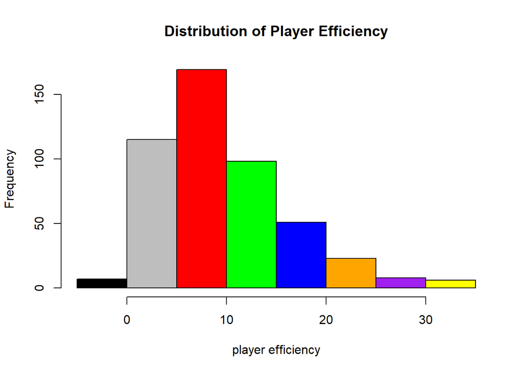

```r
#histrogram for efficiency along with colors, title, and axis-label
hist(data$efficiency, main="Distribution of Player Efficiency", col = c("black", "gray", "red", "green", "blue", "orange", "purple", "yellow"), xlab="player efficiency")
```

```r
#Player name, team, salary, and efficiency value of the top-10 players by EFF in decreasing order
data[order(data$efficiency, decreasing = TRUE),][c(1:10),][,c("player", "team", "salary", "efficiency")]
```

```
## # A tibble: 10 x 4
##    player                team  salary efficiency
##    <chr>                 <chr>  <dbl>      <dbl>
##  1 Russell Westbrook     OKC    26.5        33.8
##  2 James Harden          HOU    26.5        32.4
##  3 Anthony Davis         NOP    22.1        31.1
##  4 LeBron James          CLE    31.0        31.0
##  5 Karl-Anthony Towns    MIN     5.96       30.3
##  6 Kevin Durant          GSW    26.5        30.2
##  7 Giannis Antetokounmpo MIL     3.00       28.4
##  8 DeMarcus Cousins      NOP    17.0        27.9
##  9 Jimmy Butler          CHI    17.6        25.6
## 10 Hassan Whiteside      MIA    22.1        25.4
```

```r
#players with a negative EFF
data[data$efficiency < 0,][, c("player")]
```

```
## # A tibble: 4 x 1
##   player
##   <chr>
## 1 Gary Neal
## 2 Axel Toupane
## 3 Patricio Garino
## 4 Ben Bentil
```

# 5) Further Exploration

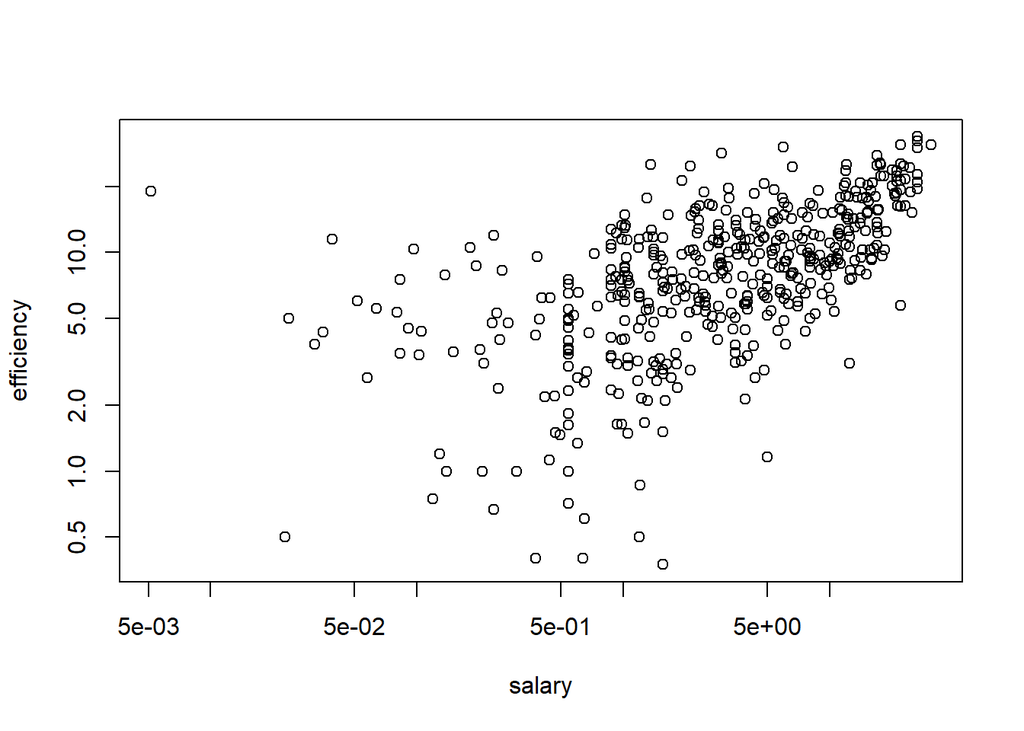

```r
#The more efficient a player is, the higher his salary?
plot(efficiency~salary, data = data ,log= "xy")
```

*Looks like there is a correlation between salary and efficiency and it is a positive relation. Hence I can say that higher the salary, higher the efficiency

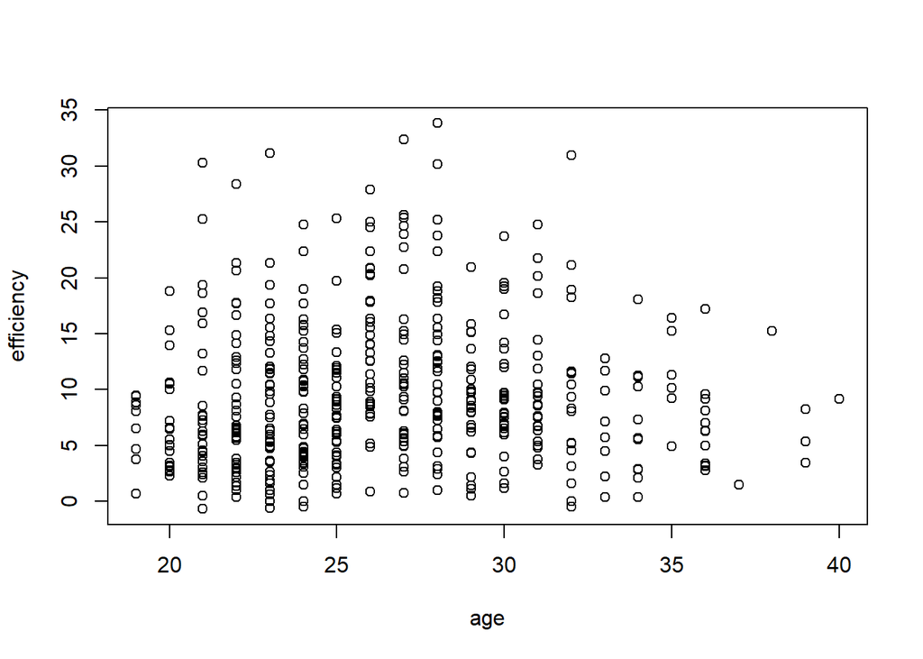

```r
#As players get older, do they tend to become more efficient?
plot(efficiency~age, data = data)
```

*There seems to be no correlation between age and efficiency. Hence it is not true that as players get older, they tend to become more efficient

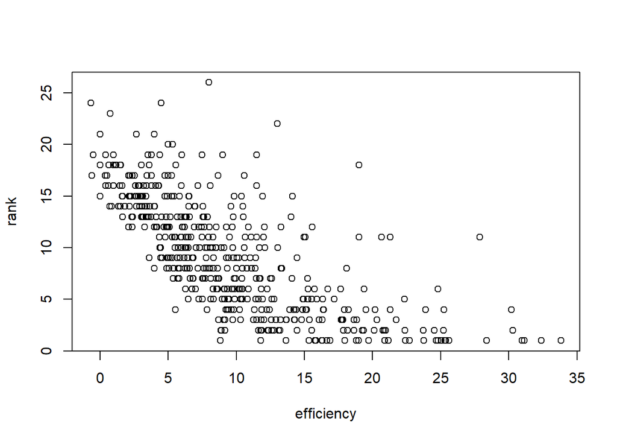

```r
#Does the rank of a player seem to be associated with his efficiency (i.e. the more importnat the rank, the more efficient)?
plot(rank~efficiency, data = data)
```

*It looks like as ranks get closer to 1, the efficiency is more concentrated on the higher side. Hence we can say that the more important the rank, the more efficient

# 6) Comments and Reflections

*It took me about 4~5 hours to complete this. I think modifying the data frame was the hard part. Plotting the graphs to find evidence for the last part of the lab was relatively on the easier side. To complete this assignment, I did have to consult some external websites to find specific commands. The most consuming part was setting up the data, assigning the data types and changing labels. I didn’t really have something that I did not understand, but figuring out how to modify data frames felt a little frustrating at first.